# SurvGPR Example

Aaron J. Molstad (amolstad@fredhutch.org)

5/28/2019

In this document, we show how to use the $\texttt{SurvGPR}$ R package. **If you encounter any errors or strange behavior, please report the issue at <github.com/ajmolstad/SurvGPR>.** First, we download the package from GitHub.

```r
library(devtools)
devtools::install_github("ajmolstad/SurvGPR")
```

Then, we create survival data from the Gaussian process regression model.

```r
library(SurvGPR)
library(MASS)
# set dimesions
set.seed(20)
n = 500
p = 1000
q = 2
train.inds <- sample(1:n, 300)
test.inds <- c(1:n)[-train.inds]

# generate gene expression kernel
SigmaX <- matrix(.5, nrow=p, ncol=p)
diag(SigmaX) <- 1
X <- mvrnorm(n = n, mu = rep(0, p), Sigma = SigmaX, tol = 1e-6)
Kout <- as.matrix(dist(X, method="euclidean"))
K1 <- exp(-Kout/max(Kout[train.inds,train.inds]))
K1.full <- exp(-Kout/max(Kout))

Z <- cbind(rep(1, n), matrix(rnorm(n*q), nrow=n))
beta <- c(6.2, -0.5, -1.2)
Sigma <- 3*K1.full
G <- mvrnorm(n = 1, mu = rep(0, n), Sigma = Sigma, tol = 1e-6)

# generate failure times
log_time <- Z%*%beta + c(G) + rnorm(n, sd=sqrt(.5))
C <- log(rexp(n=n, rate=1/quantile(exp(log_time), .8)))
y <- pmin(log_time, C)
time <- exp(y)
status <- 1*(y != C)
```

Note that the $M$ candidate kernels should be organized into an array of dimension $n_{\rm train} \times n_{\rm train} \times M$. Note that even if $M = 1$, this must still be entered as an array. In addition, each of candidate the kernels should be positive definite. In the code above, the candidate kernels are stored as $\texttt{K1}$.

Next, we fit the SurvGPR model using the following. Please note that this may take a few minutes to run.

```r
time.train <- time[train.inds]
status.train <- status[train.inds]
Z.train <- Z[train.inds, ]
K.train <- array(K1[train.inds, train.inds], dim = c(length(train.inds), length(train.inds),
    1))

# ------------------------ display inputs ------------------------
time.train[1:10]
```

```
##  [1] 421.52659  12.82139 631.46504 240.75817  89.76509 322.65780 206.41789
##  [8] 277.38934 457.97231  32.40774
```

```r
status.train[1:10]
```

```
##  [1] 1 0 1 0 0 1 1 1 1 0
```

```r
Z.train[1:10, ]
```

```
##       [,1]       [,2]        [,3]
##  [1,]    1  1.6047070  0.16164251
##  [2,]    1 -1.0999800  0.42764294
##  [3,]    1 -0.2965829  0.62351308
##  [4,]    1  0.4775841 -0.44029827
##  [5,]    1  0.9999098 -0.75503343
##  [6,]    1  1.8769275  0.59915343
##  [7,]    1  2.0396633  0.02066611
##  [8,]    1 -0.3490389 -0.63380672
##  [9,]    1  0.2104500 -0.23658373
## [10,]    1  0.5167755  0.37743189
```

```r
str(K.train)
```

```
##  num [1:300, 1:300, 1] 1 0.639 0.746 0.748 0.679 ...
```

Finally, we fit the model using the $\texttt{SurvGPR}$ function.

```r
results <- SurvGPR(time = time.train, status = status.train, Z = Z.train, K = K.train,
    tol = 1e-07, max.iter.MM = 100, max.iter = 100, quiet = FALSE, max.samples = 1e+05,
    initializer = 0)
```

```
## 1 : ASE = 0.119 ; sigma2 = 1.846 ; resid = 7.91552 ; sk = 500
## 2 : ASE = 0.027 ; sigma2 = 2.26 ; resid = 0.7413 ; sk = 500
## 3 : ASE = 0.008 ; sigma2 = 2.6 ; resid = 0.11021 ; sk = 500
## 4 : ASE = 0.005 ; sigma2 = 2.771 ; resid = 0.02287 ; sk = 500
## 5 : ASE = 0.003 ; sigma2 = 2.927 ; resid = 0.01299 ; sk = 500
## 6 : ASE = 0.001 ; sigma2 = 3.036 ; resid = 0.00436 ; sk = 500
## 7 : ASE = 0.001 ; sigma2 = 3.085 ; resid = 8e-05 ; sk = 500
## Adding samples for ascent: 1000  samples
## 7 : ASE = 0.001 ; sigma2 = 3.118 ; resid = 0.00247 ; sk = 1000
## 8 : ASE = 0 ; sigma2 = 3.12 ; resid = -0.00045 ; sk = 1000
## Adding samples for ascent: 2000  samples
## 8 : ASE = 0 ; sigma2 = 3.162 ; resid = 9e-04 ; sk = 2000
## 9 : ASE = 0 ; sigma2 = 3.16 ; resid = -0.00026 ; sk = 2000
## Adding samples for ascent: 4000  samples
## 9 : ASE = 0 ; sigma2 = 3.166 ; resid = -0.00018 ; sk = 4000
## Adding samples for ascent: 8000  samples
## 9 : ASE = 0 ; sigma2 = 3.167 ; resid = -8e-05 ; sk = 8000
## Adding samples for ascent: 16000  samples
## 9 : ASE = 0 ; sigma2 = 3.167 ; resid = 3e-05 ; sk = 16000
## Adding samples for ascent: 32000  samples
## 9 : ASE = 0 ; sigma2 = 3.168 ; resid = 0.00012 ; sk = 32000
## 10 : ASE = 0 ; sigma2 = 3.179 ; resid = 0.00034 ; sk = 32000
## 11 : ASE = 0 ; sigma2 = 3.181 ; resid = 6e-05 ; sk = 32000
## Adding samples for ascent: 64000  samples
## 11 : ASE = 0 ; sigma2 = 3.185 ; resid = 0.00015 ; sk = 64000
## 12 : ASE = 0 ; sigma2 = 3.188 ; resid = 1e-04 ; sk = 64000
## Adding samples for ascent: 128000  samples
```

Checking the output, we have a list of parameter estimates and other information needed for subsequent prediction tasks.

```r
str(results)
```

```
## List of 4
##  $ beta   : num [1:3, 1] 6.953 -0.611 -1.16
##  $ sigma2 : num [1:2] 3.188 0.244
##  $ Tout   : num [1:300] 6.04 6.66 6.45 6.71 6.54 ...
##  $ Yimpute: num [1:300] 422 1343 631 1855 1526 ...
```

For example, we can look at the estimated variance components, which are fairly accurate in this particular dataset:

```r
results$sigma2
```

```
## [1] 3.1882516 0.2443525
```

With the fitted model, we can then predict for new subjects. Note that we can also get predicted survival probabilities at certain times (on the original scale, not log-scale) by specifying times in the argument. The first two arguments should be input as shown below: $\texttt{Z} \in \mathbb{R}^{n \times p+1}$, $\texttt{K.testt} \in \mathbb{R}^{n \times n \times M}$ where $\texttt{train.inds}$ and $\texttt{test.inds}$ are a partition of $\left\{1, \dots, n\right\}$ where $\texttt{train.inds}$ denote the rows of $\texttt{Z}$ and row/columns of $\textttt{K}$ corresponding to the training subjects; and $\texttt{test.inds}$ corresponds to the testing subjects.

```r
K.test <- array(K1.full, dim = c(n, n, 1))
pred_results <- SurvGPR_Predict(results = results, barT = results$Tout, Z.full = Z,
    K.full = K.test, train.inds = train.inds, test.inds = test.inds, times = seq(0,
        max(time)/5, length = 1000))
str(pred_results)
```

```
## List of 3
##  $ test.inds: int [1:200] 1 4 7 11 12 15 19 22 24 25 ...
##  $ log.pred : num [1:200, 1] 4.22 4.66 3.53 7.13 9.53 ...
##  $ survFunc : num [1:200, 1:1000] 1 1 1 1 1 1 1 1 1 1 ...
```

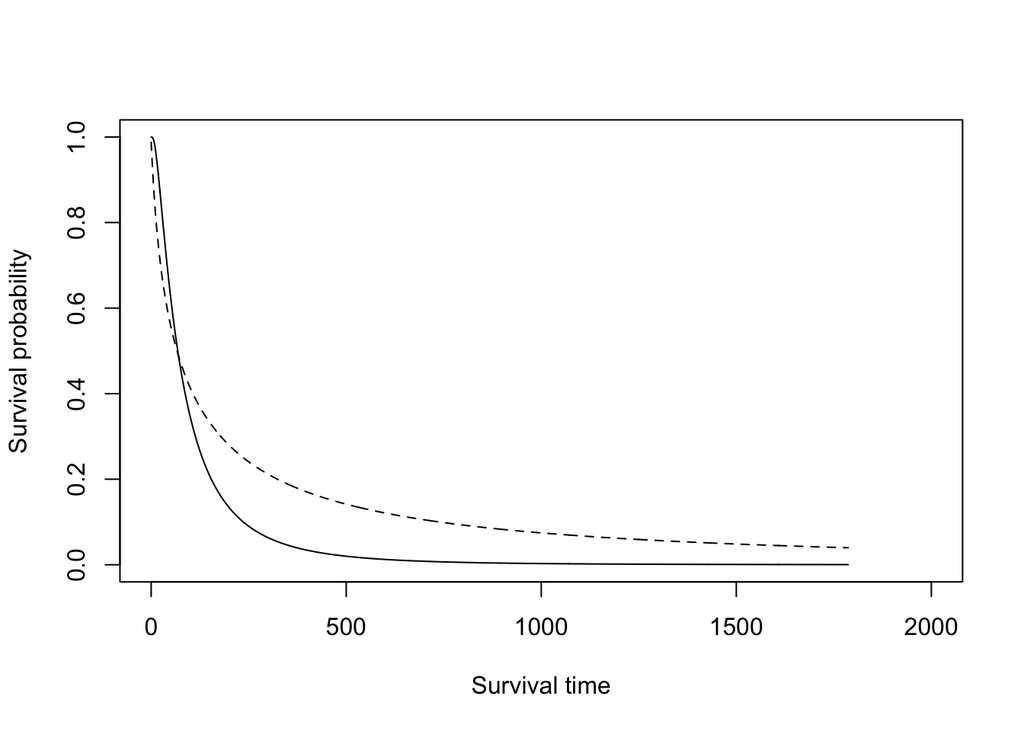

```r
plot(x = seq(0, max(time)/5, length = 1000), y = pred_results$survFunc[1, ],
    ylab = "Survival probability", xlab = "Survival time", type = "l", xlim = c(0,
        2000), ylim = c(0, 1))
lines(x = seq(0, max(time)/5, length = 1000), y = 1 - pnorm(log(seq(1, max(time)/5,
    length = 1000)), mean = c(Z[test.inds[1], ] %*% beta), sd = sqrt(3.5)),
    lty = 2)
```

We also plot our predictions versus the true log-survival times.

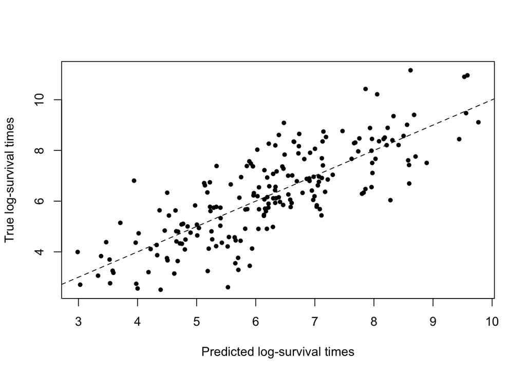

```r
plot(x = pred_results$log.pred, y = log_time[pred_results$test.inds], xlab = "Predicted log-survival times",
    ylab = "True log-survival times", pch = 20)
abline(0, 1, lty = 2)
```